# **DATA VISUALIZATION WITH ggplot2**

## **EXERCISE 2**

Recreate the following plots:

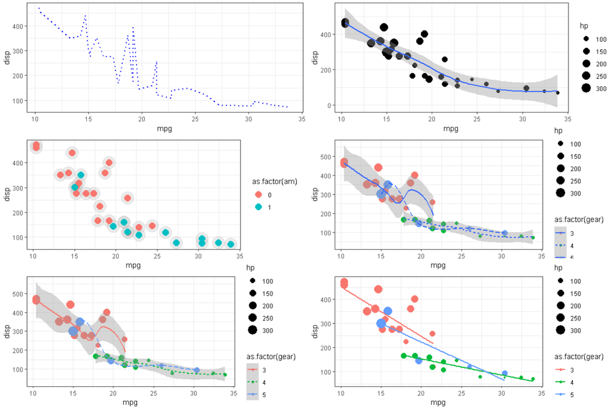

```r
# Solution

p1 <- ggplot(data = mtcars, aes(x = mpg, y = disp)) +
    geom_line(color = "blue", linetype = "dotted", size = 1)
print(p1)

p2 <- ggplot(data = mtcars, aes(x = mpg, y = disp)) +
    geom_point(aes(size = hp)) + geom_smooth()
print(p2)

p3 <- ggplot(data = mtcars, aes(x = mpg, y = disp)) +
    geom_point(alpha = 0.3, color = "gray", size = 8) +
    geom_point(aes(color = as.factor(am)), size = 4)
print(p3)

p4 <- ggplot(data = mtcars, aes(x = mpg, y = disp)) +
    geom_point(aes(color = as.factor(gear), size = hp)) +
    geom_smooth(aes(lty = as.factor(gear)))
print(p4)

p5 <- ggplot(data = mtcars, aes(x = mpg, y = disp, color = as.factor(gear))) +
    geom_point(aes(size = hp)) + geom_smooth(aes(lty = as.factor(gear)))
print(p5)

p6 <- ggplot(data = mtcars, aes(x = mpg, y = disp, color = as.factor(gear))) +
    geom_point(aes(size = hp)) + geom_smooth(method = "lm", aes(group = gear), se = F)
print(p6)
```

Now we can put them together in one canvas using the function `grid.arrange` from package `gridExtra`

```r
# Set plot width, height & resolution (optional for Jupyter Lab)
options(repr.plot.width=12, repr.plot.height=8, repr.plot.res = 100)

# Arrange multiple plots
gridExtra::grid.arrange(p1, p2, p3, p4, p5, p6,
                        ncol = 2)

# Set plot width, height & resolution (optional for Jupyter Lab)
options(repr.plot.width=6, repr.plot.height=4, repr.plot.res = 100)
```

## Stats

**What are stats?**

Stats in ggplot2 are used to transform/summarize the data in a way geoms can unterstand for plotting.

You can imagine stats as the backend, whereas geoms are the frontend of the plot.

In most cases, each stat has a default geom, and each geom has a default stat. We can either use `stat` (with nested `geom`) or vice versa to plot.

For example: plot a boxplot with a data column as input. `geom_boxplot` has the default `stat = "boxplot"`. In this cases, the stat takes raw data, calculates relevant values, passes them to the geom for plotting.

```r
#Either stat or geom will work

ggplot(data = mtcars, aes(x = mpg)) + geom_boxplot(stat = "boxplot")

ggplot(data = mtcars, aes(x = mpg)) + stat_boxplot(geom = "boxplot")
```

**When do stats matter? - Barplot vs Colplot**

In many cases, ggplot2 plots the data *as is*. Thus, many geoms have the default `stat = "identity"`.

In other cases, like the above `geom_boxplot`, certain transformations need to take place. Other examples include a barplot.

`geom_bar` has default `stat = "count"`: count observations for a category, then plot the count.

`geom_col` on the other hand has default `stat = identity`: it plots the data as is.

```r
ggplot(data = mtcars, aes(x = gear)) +
    geom_bar(stat = "count")
```

```r
# Manually compute the count table

gearCount <- mtcars %>% group_by(gear) %>% summarize(count = n())
gearCount

# Plot using geom_col
ggplot(data = gearCount, aes(x = as.factor(gear), y = count)) +
    geom_col(stat = "identity")

# Can also use geom_bar (with correct stat)
ggplot(data = gearCount, aes(x = as.factor(gear), y = count)) +
    geom_bar(stat = "identity")
```

**A boxplot with whiskers**

```r
# (A boxplot on top of an errorbar)

ggplot(data = mtcars, aes(x = mpg)) +
    geom_errorbar(stat = "boxplot", width = 0.1) +
    geom_boxplot(stat = "boxplot")
```

**Accessing calculated values from stats**

Take histogram. Though we only call one variable in `aes`, the function actually needed two variables.

`stat_bin()` calculates additional variables, which can be called using `..<VARIABLE NAME>..`. Check out https://www.rdocumentation.org/packages/ggplot2/versions/1.0.1/topics/stat_bin for the list of variables.

Here, variable `y = ..count..` was used.

We can change what is plotted on the y axis to `y = ..density..`

```r
ggplot(data = mtcars, aes(x = mpg, y = ..density..)) + geom_histogram(stat = "bin")
```

## Positions

**Positions for (grouped) barplots**

For this, we work with dataset `diamonds`.

We want to count the number of diamonds with different colors, while grouped by different types of cut (2 categorical variables).

There are three positions to display the bar plot: `stack`, `dodge` and `fill`

```r
head(diamonds)
```

```r
# Stack: default

ggplot(diamonds, aes(x = color, fill = cut)) + geom_bar(position = "stack")
```

```r
# Dodge: side-by-side

ggplot(diamonds, aes(color, fill = cut)) + geom_bar(position = "dodge")
```

```r
# Fill: Percentage

ggplot(diamonds, aes(color, fill = cut)) + geom_bar(position = "fill")
```

## Labels, Scales & Legends

**A good enough plot?**

Is the following plot good enough to be published?

```r
ggplot(data = mtcars, aes(x = mpg, y = hp)) +
    geom_point(aes(color = as.factor(cyl), shape = as.factor(gear)), size = 3, alpha = 0.7)
```

**Adding labels**

Labeling is a crucial step to make plot readable (not everybody knows what the abbreviated variable names mean)

`labs()` is used for this purpose.

```r
ggplot(data = mtcars, aes(x = mpg, y = hp)) +
    geom_point(aes(color = as.factor(cyl), shape = as.factor(gear)), size = 3, alpha = 0.7) +
    labs(title = "Cars specs comparison",
         subtitle = "Horsepower vs miles/gallon",
         x = "Miles/gallon",
         y = "Horsepower")
```

**Modifying scales**

Legend is the area describing (grouped) elements in the graph.

Scales are "dimensions" of the plot. They influences the translation from data to visualization. How many dimensions are there in the plot above?

```r
# The scales are automatically called with plots, we can make adjustments within the scales

# Change scale name
# Change axis breaks

ggplot(data = mtcars, aes(x = mpg, y = hp)) +
    geom_point(aes(color = as.factor(cyl), shape = as.factor(gear)), size = 3, alpha = 0.7) +

    scale_x_continuous(name = "Miles/gallon", breaks = seq(10, 35, 4)) +
    scale_y_continuous(name = "Horsepower") +
    scale_color_discrete() +
    scale_shape_discrete() +

    labs(title = "Cars specs comparison",
         subtitle = "Horsepower vs miles/gallon")
```

**Changing legends**

Legend is the area describing (grouped) elements in the graph, including the legend title and key values.

Everything looks much clearer now.

```r
ggplot(data = mtcars, aes(x = mpg, y = hp)) +
    geom_point(aes(color = as.factor(cyl), shape = as.factor(gear)), size = 3, alpha = 0.7) +

    scale_color_discrete(name = "# of cylinders") +
    scale_shape_discrete(name = "# of gears", label = c("Three","Four","Five")) +

    labs(title = "Cars specs comparison",
         subtitle = "Horsepower vs miles/gallon") +
    xlab("Miles/gallon") +
    ylab("Horsepower")
```

**Hiding legends**

In geom layer, add `show.legend = F`

```r
ggplot(data = mtcars, aes(x = mpg, y = hp)) +
    geom_point(aes(color = as.factor(cyl), shape = as.factor(gear)), show.legend = F, size = 3, alpha = 0.7) +
    labs(title = "Cars specs comparison",
         subtitle = "Horsepower vs miles/gallon") +
    xlab("Miles/gallon") +
    ylab("Horsepower")
```

## **EXERCISE 3**

From the dataset `diamonds`, recreate this plot:

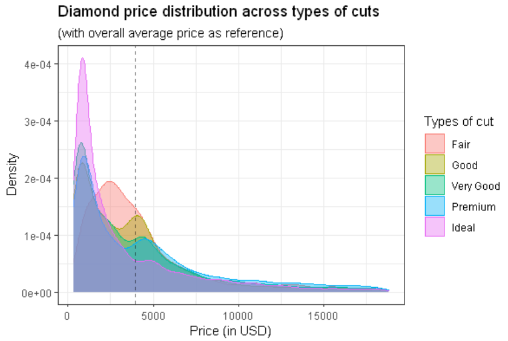

```r
# Solution

ggplot(diamonds, aes(x = price)) +
    geom_density(aes(fill = cut, color = cut), alpha = 0.4) +
    scale_fill_discrete(name = "Types of cut") +
    scale_color_discrete(name = "Types of cut") +
    geom_vline(xintercept = mean(diamonds$price), alpha = 0.5, linetype = 2) +
    labs(title = "Diamond price distribution across types of cuts", subtitle = "(with overall average price as reference)",
        x = "Price (in USD)",
        y = "Density")
```

## Facetting

**Making subplots**

Facetting helps you split your data into groups and plot them side-by-side in a similar way for comparison.

`facet_wrap` turns a long chain of subplots into rows & columns.

`facet_grid` expands a plot into subplots based on the categories of two variables.

```r
# Facet wrap
options(repr.plot.width=7, repr.plot.height=5, repr.plot.res = 100) # Set plot size

ggplot(diamonds, aes(x = price)) +
    geom_density(aes(fill = cut, color = cut), alpha = 0.4) +
    scale_fill_discrete(name = "Types of cut") +
    scale_color_discrete(name = "Types of cut") +
    geom_vline(xintercept = mean(diamonds$price), alpha = 0.5, linetype = 2) +
    labs(title = "Diamond price distribution across types of cuts", subtitle = "(with overall average price as reference)",
        x = "Price (in USD)",
        y = "Density") +

    facet_wrap(cut ~ ., ncol = 3)
```

```r
# We subset data based on two variables with facet_grid

ggplot(data = mtcars, aes(x = mpg, y = hp)) +
    geom_point(aes(color = as.factor(cyl), shape = as.factor(gear)), show.legend = F, size = 3, alpha = 0.7) +
    labs(title = "Cars specs comparison",
         subtitle = "Horsepower vs miles/gallon") +
    xlab("Miles/gallon") +
    ylab("Horsepower") +
    facet_grid(cyl ~ gear) # here is the subset
```

## Long- & Wide-Format

**Plotting groups**

Long-format: think vertical. A column contains the categories, another contains values.

`ggplot2` needs long-format data to plot groups.

```r
options(repr.plot.width=6, repr.plot.height=4, repr.plot.res = 100)

diamonds %>% select(cut, price) %>% head(10)

ggplot(diamonds, aes(x = price)) +
    geom_density(aes(fill = cut, color = cut), alpha = 0.4) +
    scale_fill_discrete(name = "Types of cut") +
    scale_color_discrete(name = "Types of cut") +
    geom_vline(xintercept = mean(diamonds$price), alpha = 0.5, linetype = 2) +
    labs(title = "Diamond price distribution across types of cuts", subtitle = "(with overall average price as reference)",
        x = "Price (in USD)",
        y = "Density")
```

**Convert wide to long data**

Some dataset are in wide-format. Wide-format: think horizontal. One row is one observation.

Use `pivot_longer` from package `tidyr` for the conversion.

Example with `iris` dataset: Plot distribution densities of the given features of the flowers

```r
head(iris)
```

```r
irisLong <- iris %>% pivot_longer(cols = -Species, names_to = "Features", values_to = "Measurement")
head(irisLong, 10)
```

```r
# Now you can create some plots with the data

irisLong %>% ggplot(aes(x = Measurement, fill = Features)) + geom_density(position = "dodge", alpha = 0.6)
irisLong %>% ggplot(aes(x = Features, y = Measurement, fill = Features)) + geom_errorbar(stat = "boxplot", width = 0.3) + geom_boxplot(show.legend = F)
```

## Coordinates

**The axes**

Coordinates deals with the two axes `x` and `y` (here we deal with linear coordinates).

**Zoom in/out**

```r
p <- ggplot(data = mtcars, aes(x = mpg, y = hp)) +
    geom_point(aes(color = as.factor(cyl), shape = as.factor(gear)), size = 3, alpha = 0.7) +
    labs(title = "Cars specs comparison",
         subtitle = "Horsepower vs miles/gallon",
         x = "Miles/gallon",
         y = "Horsepower") +
    scale_color_discrete(name = "# of cylinders") +
    scale_shape_discrete(name = "# of gears", label = c("Three","Four","Five"))


p

p + coord_cartesian(xlim = c(15, 25))
```

**Plotting a cut of data vs. Looking at a cut of the plotted data**

Both `coord_cartesian` and `scale_x_continuous` have options to limit the data shown in the plot, but in different ways.

```r
p2 <- ggplot(diamonds, aes(x = price)) + geom_histogram(color = "black", fill = "grey", bins = 20)

p2

p2 + coord_cartesian(xlim = c(5000, 10000)) + labs(title = "Zoom in the coordinate (plot data then look at a cut)")

p2 + scale_x_continuous(limits = c(5000, 10000))  + labs(title = "Zoom in the scale (plot a cut of data)")
```

**Flip the coordinates**

```r
p + coord_flip()
```

## Themes

**Aesthetic customization**

Again, `theme()` has all the control power of all non-data ink, it's the source of (endless) aesthetic customization in ggplot2.

`set_theme` sets the overall, pre-defined theme.

For further adjustments, look into the documentation to see what it can influence.

Each component in the plot falls into one of these placeholders:

- `element_text`
- `element_line`
- `element_rect`
- `element_blank`

**Change plot title text color**

```r
p + theme(plot.title = element_text(color = "blue"))
```

**Rotate the labels on x axis**

```r
options(repr.plot.width=3, repr.plot.height=3, repr.plot.res = 150)

p3 <- irisLong %>% ggplot(aes(x = Features, y = Measurement, fill = Features)) + geom_errorbar(stat = "boxplot", width = 0.3) + geom_boxplot(show.legend = F)

# Rotate label 20° and nudge it down a bit (0.6)
p3 + theme(axis.text.x = element_text(angle = 20, vjust = 0.6))

options(repr.plot.width=6, repr.plot.height=4, repr.plot.res = 150)
```

**Make the gridlines disappear**

```r
options(repr.plot.width=6, repr.plot.height=4, repr.plot.res = 100)

p + theme(panel.grid = element_blank())
```

**Wrap legends in boxes**

```r
p + theme(legend.background = element_rect(color = "gold"))
```

**Buffer/Paddling spaces on scale (and how to eliminate them)**

```r
p + scale_x_continuous(expand = c(0.1, 0.1)) +
    scale_y_continuous(expand = c(0 ,0))
```

**Dual Y axis**

```r
meanHp = mtcars %>% group_by(gear) %>% summarize(meanHp = mean(hp))

meanHp

ggplot(mtcars) +

    # Build a normal bar plot counting the number of gears
    geom_bar(mapping = aes(x = as.factor(gear), fill = as.factor(cyl))) +

    # Plot the lines and points of the second Y axis, "transforming" the values of
    # the second Y axis according to the first one
    geom_line(data = meanHp, mapping = aes(x = as.factor(gear), y = meanHp/10, group = 1), linetype = 2) +
    geom_point(data = meanHp, mapping = aes(x = as.factor(gear), y = meanHp/10), shape = 21, fill = "blue", color = "black", size = 5) +

    # Set up the two Y axis, transforming back the second one
    scale_y_continuous(name = "Count",
                       sec.axis = sec_axis(trans = ~.*10,
                                           name = "Mean Hp")) +

    # Aesthetics setup
    scale_fill_brewer(name = "# of cylinders", palette = "Set1") +
    labs(title = "Distribution of cars based on numbers of gear",
         subtitle = "with average Horsepower of each group",
         x = "Number of gears") +
    theme(axis.title.y.right = element_text(color = "blue"))
```

## Do we still need base R plots?

```r
options(repr.plot.width=4, repr.plot.height=3, repr.plot.res = 100)

x <- c(1,3,5,6)
y <- c(5,6,8,3)

# Base R
plot(x,y)
abline(h = 4)

# ggplot2
data <- data.frame(x, y)
ggplot(data, aes(x = x, y = y)) + geom_point() + geom_hline(yintercept = 4)
```

```r
# Quick plot in ggplot2
qplot(x,y)
```

## Sources

- ggplot2 Book: https://ggplot2-book.org/
- tidyverse documentation: https://ggplot2.tidyverse.org/
- Cheatsheets: https://rstudio.com/resources/cheatsheets/
- Lisa Gotzian's slides

[figure not shown]